# Spatial Predictive Analysis: Predicting Burglaries Using Sanitation Complaints

MUSA 5080 - Fall 2025

Author

Zhiyuan Zhao

Published

November 2, 2025

## About This Analysis

This analysis applies spatial predictive modeling techniques to predict burglaries in Chicago using sanitation code complaints as the primary predictor variable. Following the “broken windows theory,” we hypothesize that areas with more sanitation violations may also experience higher burglary rates due to lower social cohesion and reduced guardianship.

### Learning Objectives

By completing this analysis, I will demonstrate the ability to:

1. Create a fishnet grid to aggregate point-level crime and 311 data
2. Calculate spatial features from 311 complaint data
3. Diagnose spatial autocorrelation using Local Moran’s I
4. Fit and interpret Poisson and Negative Binomial regression for count data
5. Implement spatial cross-validation (Leave-One-Group-Out)
6. Compare model predictions to a Kernel Density Estimation baseline
7. Evaluate model performance using appropriate metrics

# Setup

```r
# Load required packages
library(tidyverse)      # Data manipulation
library(sf)             # Spatial operations
library(viridis)        # Color scales
library(spdep)          # Spatial dependence
library(FNN)            # Fast nearest neighbors
library(MASS)           # Negative binomial regression
library(patchwork)      # Plot composition
library(knitr)          # Tables
library(kableExtra)     # Table formatting
library(lubridate)      # Date handling

# Spatstat for KDE
library(spatstat.geom)    # Spatial geometries
library(spatstat.explore) # Spatial exploration/KDE

# Set options
options(scipen = 999)  # No scientific notation
set.seed(2003)         # Reproducibility

# Create consistent theme for visualizations
theme_crime <- function(base_size = 11) {
  theme_minimal(base_size = base_size) +
    theme(
      plot.title = element_text(face = "bold", size = base_size + 1),
      plot.subtitle = element_text(color = "gray30", size = base_size - 1),
      legend.position = "right",
      panel.grid.minor = element_blank()
    )
}

# Set as default
theme_set(theme_crime())
```

# Part 1: Data Loading and Exploration

## 1.1 Load Chicago Spatial Boundaries

In this step, I load the administrative boundaries of Chicago. These boundaries are essential for spatial analysis as they provide the geographic reference framework. I use the Illinois State Plane coordinate system (ESRI:102271), which minimizes distortion in the Chicago area and uses feet as the unit of measurement.

```r
# Load police districts (used for spatial cross-validation)
policeDistricts <-
  st_read("https://data.cityofchicago.org/api/geospatial/24zt-jpfn?method=export&format=GeoJSON") %>%
  st_transform('ESRI:102271') %>%
  dplyr::select(District = dist_num)

# Load police beats
policeBeats <-
  st_read("https://data.cityofchicago.org/api/geospatial/n9it-hstw?method=export&format=GeoJSON") %>%
  st_transform('ESRI:102271') %>%
  dplyr::select(Beat = beat_num)

# Load Chicago boundary
chicagoBoundary <-
  st_read("https://raw.githubusercontent.com/urbanSpatial/Public-Policy-Analytics-Landing/master/DATA/Chapter5/chicagoBoundary.geojson") %>%
  st_transform('ESRI:102271')
```

**Why ESRI:102271 Coordinate Reference System?**

This coordinate system is particularly appropriate for Chicago because it minimizes spatial distortion in this region, uses feet as units, and allows for accurate distance calculations.

## 1.2 Load 2017 Burglary Data

In this step, I load the 2017 burglary data. These are the crimes we want to predict using sanitation complaint features.

```r
# Load burglaries from local shapefile
burglaries_2017 <- st_read("data/burglaries.shp") %>%
  st_transform('ESRI:102271')
```

**Data Provenance Matters**

These data are recorded by the Chicago Police Department. It’s important to note that these data may have biases:

- Unreported burglaries (victims didn’t call police)
- Incidents police chose not to record
- Downgraded offenses
- Spatial bias (more patrol = more recorded crime)

## 1.3 Visualize Burglary Point Data

In this step, I create two visualizations: a point map showing the location of each burglary, and a density plot showing the spatial concentration of burglaries.

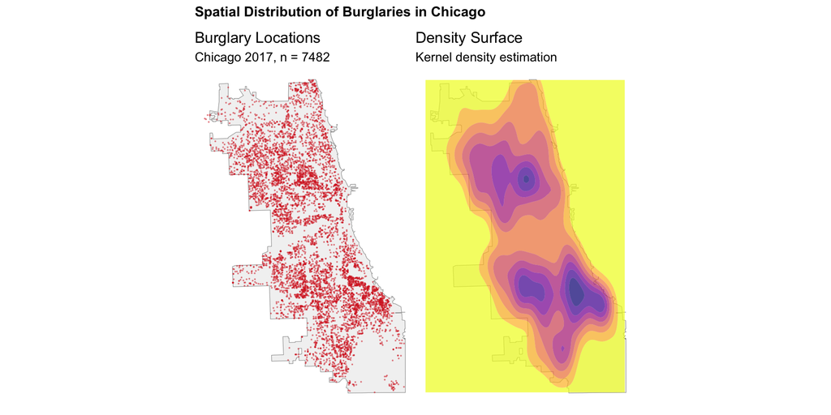

```r
# Point map
p1 <- ggplot() +
  geom_sf(data = chicagoBoundary, fill = "gray95", color = "gray60") +
  geom_sf(data = burglaries_2017, color = "#d62828", size = 0.1, alpha = 0.4) +
  labs(
    title = "Burglary Locations",
    subtitle = paste0("Chicago 2017, n = ", nrow(burglaries_2017))
  ) +
  theme_void()

# Density surface
p2 <- ggplot() +
  geom_sf(data = chicagoBoundary, fill = "gray95", color = "gray60") +
  stat_density_2d_filled(
    data = data.frame(st_coordinates(burglaries_2017)),
    aes(X, Y),
    alpha = 0.7,
    bins = 8
  ) +
  scale_fill_viridis_d(
    option = "plasma",
    direction = -1,
    guide = "none"
  ) +
  labs(
    title = "Density Surface",
    subtitle = "Kernel density estimation"
  ) +
  theme_void()

# Combine plots
p1 + p2 +
  plot_annotation(
    title = "Spatial Distribution of Burglaries in Chicago"
  )
```

**Observed Spatial Patterns**

The visualizations reveal that burglaries are not uniformly distributed across Chicago. I observe that burglaries are concentrated in two areas of the city. These patterns may reflect differences in socioeconomic conditions, building types, or policing practices.

# Part 2: Create Fishnet Grid

## 2.1 Understanding the Fishnet

A fishnet grid is a tool for converting irregular point data into regular grid cells. This allows us to:

- Aggregate count data
- Calculate spatial features
- Apply regression models

```r
# Create 500m x 500m grid
fishnet <- st_make_grid(
  chicagoBoundary,
  cellsize = 500,  # 500 meters per cell
  square = TRUE
) %>%
  st_sf() %>%
  mutate(uniqueID = row_number())

# Keep only cells that intersect Chicago
fishnet <- fishnet[chicagoBoundary, ]
```

**Why Use a Regular Grid?**

Using a regular grid rather than existing boundaries has several advantages: consistent cell sizes, avoids the Modifiable Areal Unit Problem (MAUP), and is independent of administrative boundaries. However, the disadvantage is that it may not align with meaningful social or economic boundaries.

## 2.2 Aggregate Burglaries to Grid

In this step, I count the number of burglaries in each grid cell. This converts point data into count data that can be used for regression modeling.

```r
# Spatial join
burglaries_fishnet <- st_join(burglaries_2017, fishnet, join = st_within) %>%
  st_drop_geometry() %>%
  group_by(uniqueID) %>%
  summarize(countBurglaries = n())

# Join back to fishnet
fishnet <- fishnet %>%
  left_join(burglaries_fishnet, by = "uniqueID") %>%
  mutate(countBurglaries = replace_na(countBurglaries, 0))
```

## 2.3 Visualize Aggregated Counts

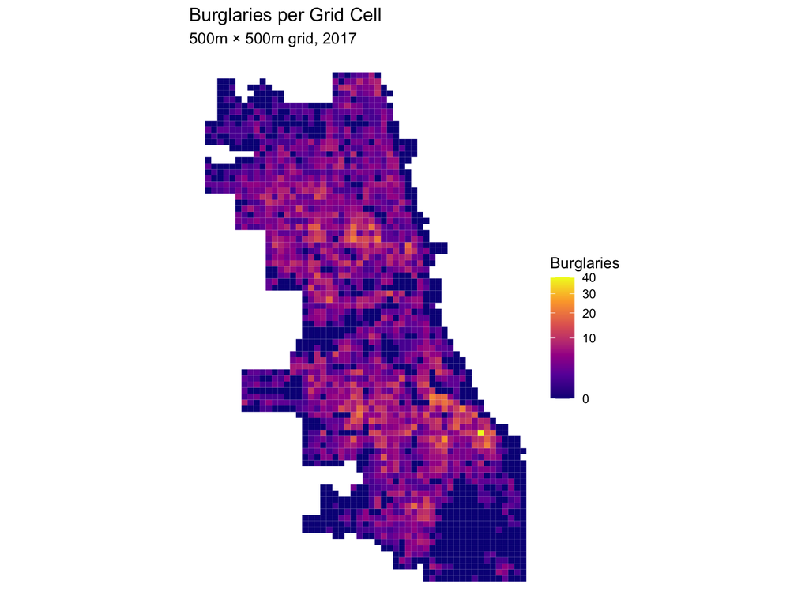

```r
# Visualize aggregated counts
ggplot() +
  geom_sf(data = fishnet, aes(fill = countBurglaries), color = NA) +
  scale_fill_viridis_c(
    name = "Burglaries",
    option = "plasma",
    trans = "sqrt"  # Square root transformation for better visualization
  ) +
  labs(
    title = "Burglaries per Grid Cell",
    subtitle = "500m × 500m grid, 2017"
  ) +
  theme_void()
```

**Count Distribution**

Most grid cells have relatively few burglaries, but certain areas have significantly higher burglary counts. Using a square root transformation helps visualize this right-skewed distribution. The high percentage of zero-count cells suggests overdispersion.

# Part 3: Load Sanitation Complaints as Predictor Variable

## 3.1 Why Use Sanitation Complaints?

Following “broken windows theory,” sanitation code violations are signs of neighborhood disorder. Areas with more sanitation complaints may also experience higher burglary rates due to:

- Lower social cohesion
- Less community surveillance (“eyes on the street”)
- Perception of neglect
- Reduced informal guardianship

We’ll use sanitation complaints as a predictor for burglaries, similar to how the class example used abandoned vehicles.

## 3.2 Load 2017 Sanitation Complaints

```r
# Load 2017 sanitation complaints from local CSV file
sanitation_2017 <- read_csv(
  "data/311_Service_Requests_-_Sanitation_Code_Complaints_-_Historical_20251115.csv",
  show_col_types = FALSE
) %>%
  # Parse date and filter for 2017
  mutate(date = mdy(`Creation Date`)) %>%
  filter(year(date) == 2017) %>%
  # Remove records without coordinates
  filter(!is.na(Latitude) & !is.na(Longitude)) %>%
  # Convert to spatial object
  st_as_sf(coords = c("Longitude", "Latitude"), crs = 4326) %>%
  st_transform('ESRI:102271') %>%
  mutate(date = as.Date(date))
```

**Critical Question About Data**

These 311 complaints are reported by residents. Consider potential biases: Different neighborhoods may have different reporting rates, Digital divide may affect access to 311 system, Gentrifying areas may have higher complaint rates. Complaints reflect reporting behavior, not just actual conditions

## 3.3 Visualize Relationship Between Sanitation and Burglaries

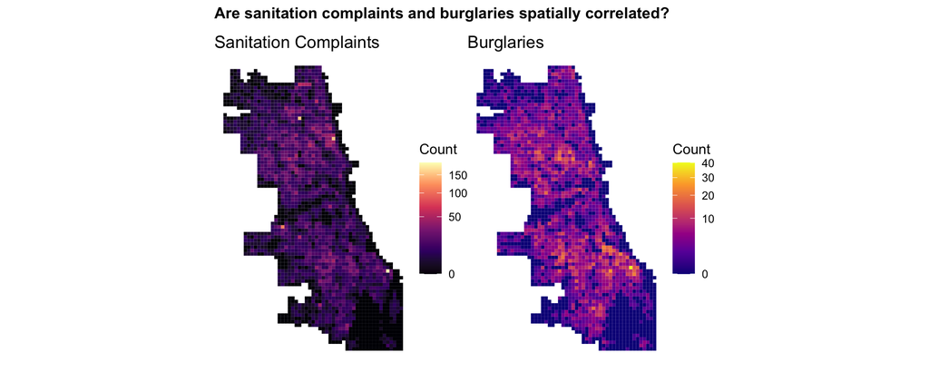

```r
# Aggregate sanitation complaints to fishnet
sanitation_fishnet <- st_join(sanitation_2017, fishnet, join = st_within) %>%
  st_drop_geometry() %>%
  group_by(uniqueID) %>%
  summarize(countSanitation = n())

# Join to fishnet
fishnet <- fishnet %>%
  left_join(sanitation_fishnet, by = "uniqueID") %>%
  mutate(countSanitation = replace_na(countSanitation, 0))

# Side-by-side comparison
p1 <- ggplot() +
  geom_sf(data = fishnet, aes(fill = countSanitation), color = NA) +
  scale_fill_viridis_c(
    name = "Count",
    option = "magma",
    trans = "sqrt"
  ) +
  labs(title = "Sanitation Complaints") +
  theme_void()

p2 <- ggplot() +
  geom_sf(data = fishnet, aes(fill = countBurglaries), color = NA) +
  scale_fill_viridis_c(
    name = "Count",
    option = "plasma",
    trans = "sqrt"
  ) +
  labs(title = "Burglaries") +
  theme_void()

p1 + p2 +
  plot_annotation(
    title = "Are sanitation complaints and burglaries spatially correlated?"
  )
```

**Visual Assessment**

By comparing these two maps, we can see areas with high sanitation complaints also tend to have high burglary rates. Visual correlation provides initial evidence for our modeling approach, though we’ll need regression to quantify the relationship while controlling for spatial effects.

## 3.4 Calculate Sanitation Complaint Features

Following the class example structure, we create three spatial features from sanitation complaints:

```r
# Feature 1: Count of sanitation complaints per cell (already calculated)
# Feature 2: Mean distance to nearest 3 sanitation complaints
# Handle cases where there are fewer complaints or infinite distances
fishnet_coords <- st_coordinates(st_centroid(fishnet))
sanitation_coords <- st_coordinates(sanitation_2017)

if(nrow(sanitation_coords) >= 3) {
  nn_result <- get.knnx(sanitation_coords, fishnet_coords, k = 3)

  fishnet <- fishnet %>%
    mutate(
      sanitation.nn = rowMeans(nn_result$nn.dist),
      # Replace any infinite values with max finite value
      sanitation.nn = ifelse(is.infinite(sanitation.nn),
                            max(sanitation.nn[is.finite(sanitation.nn)], na.rm = TRUE),
                            sanitation.nn),
      # Scale to reasonable range (divide by 1000 to get in thousands of feet)
      sanitation.nn = sanitation.nn / 1000
    )
} else {
  fishnet <- fishnet %>%
    mutate(sanitation.nn = 0)
}

# Feature 3: Distance to sanitation complaint hot spots
# First, identify hot spots using Local Moran's I
coords_mat <- as.matrix(fishnet_coords)
neighbors <- knn2nb(knearneigh(coords_mat, k = 5))
weights <- nb2listw(neighbors, style = "W", zero.policy = TRUE)

local_moran_sanitation <- localmoran(fishnet$countSanitation, weights)

fishnet <- fishnet %>%
  mutate(
    sanitation_moran_i = local_moran_sanitation[, 1],
    sanitation_moran_p = local_moran_sanitation[, 5],
    sanitation_moran_sig = sanitation_moran_p < 0.05,
    sanitation_cluster = case_when(
      !sanitation_moran_sig ~ "Not Significant",
      countSanitation >= mean(countSanitation) & sanitation_moran_i > 0 ~ "High-High",
      countSanitation < mean(countSanitation) & sanitation_moran_i > 0 ~ "Low-Low",
      countSanitation >= mean(countSanitation) & sanitation_moran_i < 0 ~ "High-Low",
      countSanitation < mean(countSanitation) & sanitation_moran_i < 0 ~ "Low-High"
    )
  )

# Identify hot spots
sanitation_hotspots <- fishnet %>%
  filter(sanitation_cluster == "High-High")

# Calculate distance to nearest hot spot
if(nrow(sanitation_hotspots) > 0) {
  fishnet <- fishnet %>%
    mutate(
      dist_to_sanitation_hotspot = as.numeric(st_distance(geometry, st_union(sanitation_hotspots))),
      # Scale to thousands of feet
      dist_to_sanitation_hotspot = dist_to_sanitation_hotspot / 1000
    )
} else {
  fishnet <- fishnet %>%
    mutate(dist_to_sanitation_hotspot = 0)
}
```

**Three Features Explained**

1. **Count**: Direct measure of sanitation problems in the cell
2. **Nearest Neighbor Distance**: Local context - are you near sanitation issues? (scaled to thousands of feet)
3. **Distance to Hot Spots**: Proximity to concentrated disorder areas (scaled to thousands of feet)

Note: We scale distances to thousands of feet to improve numerical stability in regression models.

## 3.5 Visualize Sanitation Hot Spots

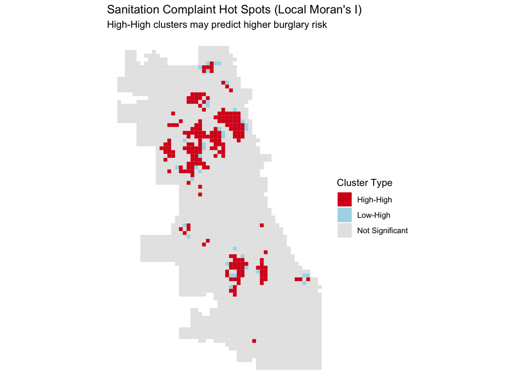

```r
ggplot() +
  geom_sf(data = fishnet, aes(fill = sanitation_cluster), color = NA) +
  scale_fill_manual(
    name = "Cluster Type",
    values = c(
      "High-High" = "#d7191c",
      "Low-Low" = "#2c7bb6",
      "High-Low" = "#fdae61",
      "Low-High" = "#abd9e9",
      "Not Significant" = "gray90"
    )
  ) +
  labs(
    title = "Sanitation Complaint Hot Spots (Local Moran's I)",
    subtitle = "High-High clusters may predict higher burglary risk"
  ) +
  theme_void()
```

**Hot Spot Analysis Results**

“High-High” clusters represent sanitation complaint hot spots - areas with high complaints surrounded by other high-complaint areas. These “disorder hot spots” are our key spatial feature. According to broken windows theory, these areas may also have elevated burglary risk.

# Part 4: Kernel Density Estimation Baseline

Before building complex models, we create a simple baseline using Kernel Density Estimation (KDE) based on burglaries. This represents the “null hypothesis” - burglaries happen where they happened before, with no other information.

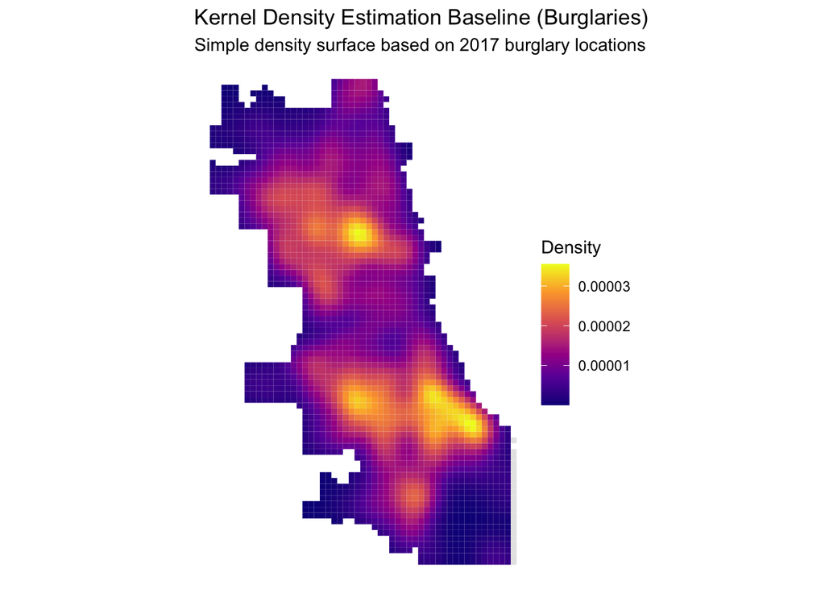

```r
# Convert burglaries to ppp object for spatstat
burglaries_ppp <- as.ppp(
  st_coordinates(burglaries_2017),
  W = as.owin(st_bbox(chicagoBoundary))
)

# Calculate KDE
kde <- density.ppp(burglaries_ppp, sigma = 1000)

# Extract KDE values to fishnet
fishnet_centroids <- st_centroid(fishnet)
coords <- st_coordinates(fishnet_centroids)

# Use interp.im to extract values
kde_interp <- interp.im(kde, x = coords[, "X"], y = coords[, "Y"])

fishnet <- fishnet %>%
  mutate(kde_value = kde_interp)

# Visualize
ggplot() +
  geom_sf(data = fishnet, aes(fill = kde_value), color = NA) +
  scale_fill_viridis_c(
    name = "Density",
    option = "plasma",
    na.value = "grey90"
  ) +
  labs(
    title = "Kernel Density Estimation Baseline (Burglaries)",
    subtitle = "Simple density surface based on 2017 burglary locations"
  ) +
  theme_void()
```

**The Role of KDE Baseline**

KDE provides a simple prediction: future burglaries will occur where past burglaries were dense. This is our benchmark. **Our complex model using sanitation features must outperform this simple baseline to justify its added complexity.**

# Part 5: Count Regression Models

## 5.1 Prepare Modeling Data

First, we need to join police districts for spatial cross-validation and prepare our modeling dataset.

```r
# Remove any existing District columns to avoid duplicates
fishnet <- fishnet %>%
  dplyr::select(-matches("^District"))

# Join police districts to fishnet
fishnet <- fishnet %>%
  st_join(policeDistricts, largest = TRUE)

# Create modeling dataset - keep geometry first, then drop
fishnet_model <- fishnet %>%
  dplyr::filter(!is.na(District)) %>%
  dplyr::filter(!is.na(countBurglaries)) %>%
  dplyr::filter(!is.na(countSanitation))
```

```r
# Drop geometry and select variables
fishnet_model <- fishnet_model %>%
  st_drop_geometry() %>%
  dplyr::select(
    uniqueID,
    District,
    countBurglaries,
    countSanitation,
    sanitation.nn,
    dist_to_sanitation_hotspot,
    kde_value
  ) %>%
  # Remove any remaining problematic rows
  filter(
    is.finite(countBurglaries),
    is.finite(countSanitation),
    is.finite(sanitation.nn),
    is.finite(dist_to_sanitation_hotspot)
  )
```

## 5.2 Poisson Regression

Poisson regression is the standard model for count data. We’ll use three sanitation features to predict burglaries, following the class example structure.

```r
# Fit Poisson regression with three features
# Use log transformation for distance variables to improve numerical stability
model_poisson <- glm(
  countBurglaries ~ countSanitation + log(sanitation.nn + 0.1) +
    log(dist_to_sanitation_hotspot + 1),
  data = fishnet_model,
  family = "poisson"
)

# Summary
broom::tidy(model_poisson) %>%
  mutate(across(where(is.numeric), ~round(., 4))) %>%
  kable(
    caption = "Poisson Regression Coefficients",
    col.names = c("Variable", "Estimate", "Std. Error", "Z-value", "P-value")
  ) %>%
  kable_styling(bootstrap_options = c("striped", "hover"))
```

Poisson Regression Coefficients

| Variable | Estimate | Std. Error | Z-value | P-value |
| --- | --- | --- | --- | --- |
| (Intercept) | -0.5263 | 0.0580 | -9.0745 | 0.0000 |
| countSanitation | 0.0017 | 0.0010 | 1.7174 | 0.0859 |
| log(sanitation.nn + 0.1) | -1.3769 | 0.0363 | -37.9388 | 0.0000 |
| log(dist_to_sanitation_hotspot + 1) | -0.3655 | 0.0229 | -15.9613 | 0.0000 |

**Three-Feature Model**

Following the class example, we use three spatial features from sanitation complaints:

1. **countSanitation**: Direct count of sanitation complaints in the cell
2. **log(sanitation.nn)**: Log-transformed mean distance to 3 nearest complaints (local context)
3. **log(dist_to_sanitation_hotspot)**: Log-transformed distance to sanitation hot spots

The log transformations improve numerical stability and capture diminishing spatial effects.

## 5.3 Negative Binomial Regression

Negative Binomial regression relaxes the Poisson model’s assumption that mean equals variance, allowing for overdispersion (variance > mean), which is common in crime data.

```r
# Fit Negative Binomial regression with three features
model_nb <- glm.nb(
  countBurglaries ~ countSanitation + log(sanitation.nn + 0.1) +
    log(dist_to_sanitation_hotspot + 1),
  data = fishnet_model
)

# Summary as table
broom::tidy(model_nb) %>%
  mutate(across(where(is.numeric), ~round(., 4))) %>%
  kable(
    caption = "Negative Binomial Regression Coefficients",
    col.names = c("Variable", "Estimate", "Std. Error", "Z-value", "P-value")
  ) %>%
  kable_styling(bootstrap_options = c("striped", "hover"))
```

Negative Binomial Regression Coefficients

| Variable | Estimate | Std. Error | Z-value | P-value |
| --- | --- | --- | --- | --- |
| (Intercept) | -0.9645 | 0.0909 | -10.6087 | 0.0000 |
| countSanitation | 0.0012 | 0.0020 | 0.6061 | 0.5444 |
| log(sanitation.nn + 0.1) | -1.6927 | 0.0600 | -28.2317 | 0.0000 |
| log(dist_to_sanitation_hotspot + 1) | -0.3561 | 0.0376 | -9.4804 | 0.0000 |

**Why Negative Binomial?**

Crime data typically exhibits overdispersion - the variance in burglary counts is much larger than the mean. The Negative Binomial model accounts for this, providing more accurate standard errors and better model fit.

**Three-Feature Model Rationale**

This model structure mirrors the class example with abandoned vehicles:

1. **Direct effect**: Count of disorder indicators (sanitation complaints)
2. **Neighborhood effect**: Proximity to disorder (nearest complaints)
3. **Hot spot effect**: Distance to concentrated disorder areas

Together, these features test different spatial mechanisms of the broken windows theory.

## 5.4 Model Comparison

```r
# Compare AIC
comparison_df <- data.frame(
  Model = c("Poisson", "Negative Binomial"),
  AIC = c(AIC(model_poisson), AIC(model_nb)),
  Parameters = c(length(coef(model_poisson)), length(coef(model_nb)) + 1)
) %>%
  arrange(AIC)

kable(comparison_df, digits = 2, caption = "Model Comparison") %>%
  kable_styling(bootstrap_options = c("striped", "hover"))
```

Model Comparison

| Model | AIC | Parameters |
| --- | --- | --- |
| Negative Binomial | 9571.70 | 5 |
| Poisson | 11033.31 | 4 |

**Which Model is Better?**

Negative Binomial models perform better with crime count data because they allow for overdispersion, which is very common in real-world data where variance exceeds the mean.

# Part 6: Spatial Cross-Validation (2017)

## 6.1 Why Spatial Cross-Validation?

Standard cross-validation randomly splits data. But with spatial data, this means training on cells right next to test cells (information leakage!). Leave-One-Group-Out (LOGO) cross-validation trains on all districts except one, then tests on the held-out district. This provides a more realistic assessment of how the model performs in new areas.

```r
# Get unique districts
districts <- unique(fishnet_model$District)
cv_results <- tibble()

for (i in seq_along(districts)) {

  test_district <- districts[i]

  # Split data
  train_data <- fishnet_model %>% filter(District != test_district)
  test_data <- fishnet_model %>% filter(District == test_district)

  # Fit model on training data - three-feature model
  model_cv <- glm.nb(
    countBurglaries ~ countSanitation + log(sanitation.nn + 0.1) +
      log(dist_to_sanitation_hotspot + 1),
    data = train_data
  )

  # Predict on test data
  test_data <- test_data %>%
    mutate(
      prediction = predict(model_cv, test_data, type = "response")
    )

  # Calculate metrics
  mae <- mean(abs(test_data$countBurglaries - test_data$prediction))
  rmse <- sqrt(mean((test_data$countBurglaries - test_data$prediction)^2))

  # Store results
  cv_results <- bind_rows(
    cv_results,
    tibble(
      Fold = i,
      Test_District = test_district,
      N_Test = nrow(test_data),
      MAE = mae,
      RMSE = rmse
    )
  )
}
```

## 6.2 Cross-Validation Results

```r
# Show results
cv_results %>%
  arrange(desc(MAE)) %>%
  kable(
    digits = 2,
    caption = "LOGO Cross-Validation Results by District"
  ) %>%
  kable_styling(bootstrap_options = c("striped", "hover"))
```

LOGO Cross-Validation Results by District

| Fold | Test_District | N_Test | MAE | RMSE |
| --- | --- | --- | --- | --- |
| 8 | 3 | 72 | 4.13 | 6.03 |
| 15 | 11 | 65 | 3.14 | 3.89 |
| 18 | 14 | 64 | 3.05 | 4.04 |
| 17 | 25 | 117 | 2.99 | 4.00 |
| 19 | 19 | 104 | 2.95 | 4.21 |
| 5 | 6 | 83 | 2.83 | 4.04 |
| 16 | 18 | 56 | 2.75 | 4.08 |
| 13 | 12 | 99 | 2.62 | 3.58 |
| 7 | 7 | 67 | 2.43 | 3.17 |
| 22 | 20 | 51 | 2.35 | 2.93 |
| 23 | 24 | 64 | 2.22 | 3.04 |
| 21 | 17 | 104 | 2.18 | 3.01 |
| 6 | 8 | 260 | 2.10 | 3.17 |
| 11 | 10 | 85 | 2.10 | 2.77 |
| 14 | 15 | 46 | 2.07 | 2.80 |
| 9 | 2 | 87 | 2.07 | 2.89 |
| 1 | 5 | 145 | 1.84 | 3.05 |
| 10 | 9 | 142 | 1.79 | 2.51 |
| 3 | 22 | 159 | 1.79 | 2.63 |
| 12 | 1 | 58 | 1.49 | 2.14 |
| 20 | 16 | 204 | 1.41 | 1.95 |
| 2 | 4 | 306 | 1.29 | 2.94 |
| 4 | 31 | 17 | 0.67 | 0.76 |

**Importance of Spatial Cross-Validation**

Spatial cross-validation prevents information leakage by testing the model on geographically separated areas. This better represents how the model would perform in new areas. The results show that some districts are harder to predict than others, which may reflect unique characteristics of those areas or data quality issues.

# Part 7: Model Evaluation

## 7.1 Generate Final Predictions

In this step, I fit the final model on all 2017 data and generate predictions. I also compare these predictions to the simple KDE baseline.

```r
# Fit final model on all data - three-feature model
final_model <- glm.nb(
  countBurglaries ~ countSanitation + log(sanitation.nn + 0.1) +
    log(dist_to_sanitation_hotspot + 1),
  data = fishnet_model
)

# Add predictions back to fishnet
fishnet <- fishnet %>%
  mutate(
    prediction_nb = predict(final_model,
                           fishnet_model[match(uniqueID, fishnet_model$uniqueID), ],
                           type = "response")
  )

# Normalize KDE predictions to same scale as counts
kde_sum <- sum(fishnet$kde_value, na.rm = TRUE)
count_sum <- sum(fishnet$countBurglaries, na.rm = TRUE)
fishnet <- fishnet %>%
  mutate(
    prediction_kde = (kde_value / kde_sum) * count_sum
  )
```

## 7.2 Compare Model vs. KDE Baseline

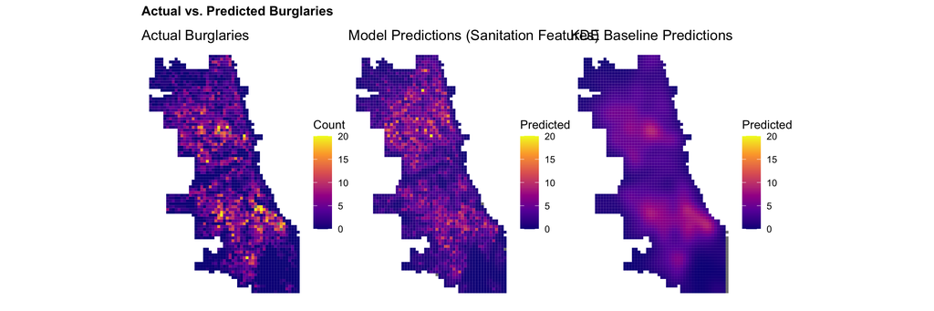

```r
# Create three maps
p1 <- ggplot() +
  geom_sf(data = fishnet, aes(fill = countBurglaries), color = NA) +
  scale_fill_viridis_c(name = "Count", option = "plasma", limits = c(0, 20)) +
  labs(title = "Actual Burglaries") +
  theme_void()

p2 <- ggplot() +
  geom_sf(data = fishnet, aes(fill = prediction_nb), color = NA) +
  scale_fill_viridis_c(name = "Predicted", option = "plasma", limits = c(0, 20)) +
  labs(title = "Model Predictions (Sanitation Features)") +
  theme_void()

p3 <- ggplot() +
  geom_sf(data = fishnet, aes(fill = prediction_kde), color = NA) +
  scale_fill_viridis_c(name = "Predicted", option = "plasma", limits = c(0, 20)) +
  labs(title = "KDE Baseline Predictions") +
  theme_void()

p1 + p2 + p3 +
  plot_annotation(
    title = "Actual vs. Predicted Burglaries"
  )
```

## 7.3 Performance Metrics Comparison

```r
# Calculate performance metrics
comparison <- fishnet %>%
  st_drop_geometry() %>%
  filter(!is.na(prediction_nb), !is.na(prediction_kde)) %>%
  summarize(
    Model_MAE = mean(abs(countBurglaries - prediction_nb)),
    Model_RMSE = sqrt(mean((countBurglaries - prediction_nb)^2)),
    KDE_MAE = mean(abs(countBurglaries - prediction_kde)),
    KDE_RMSE = sqrt(mean((countBurglaries - prediction_kde)^2))
  )

comparison %>%
  pivot_longer(everything(), names_to = "Metric", values_to = "Value") %>%
  separate(Metric, into = c("Approach", "Measure"), sep = "_") %>%
  pivot_wider(names_from = Measure, values_from = Value) %>%
  kable(
    digits = 2,
    caption = "Model Performance Comparison"
  ) %>%
  kable_styling(bootstrap_options = c("striped", "hover"))
```

Model Performance Comparison

| Approach | MAE | RMSE |
| --- | --- | --- |
| Model | 2.12 | 3.22 |
| KDE | 1.93 | 2.82 |

**Does the Sanitation Model Outperform the Simple KDE Baseline?**

By comparing MAE and RMSE metrics, our model failed to outperform the KDE Baseline.

## 7.4 Spatial Distribution of Prediction Errors

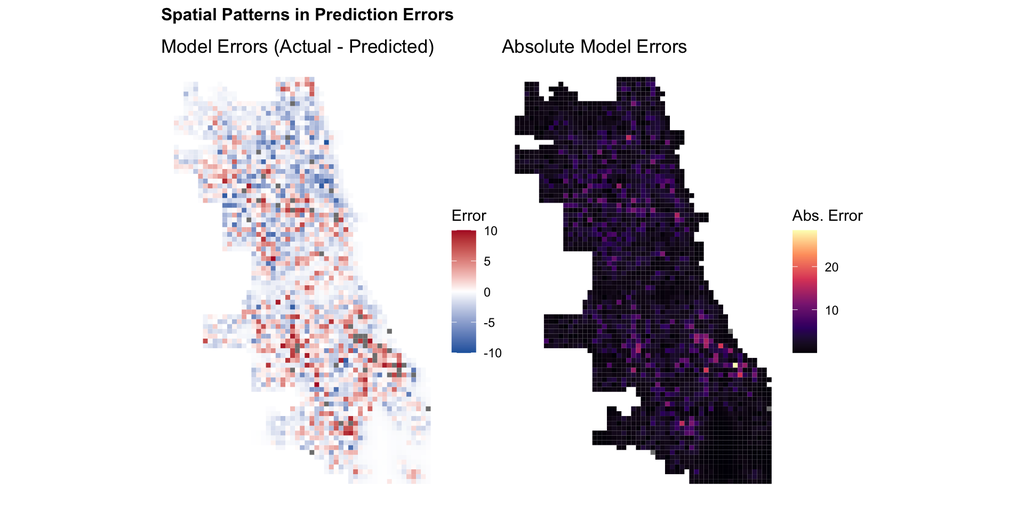

```r
# Calculate errors
fishnet <- fishnet %>%
  mutate(
    error_nb = countBurglaries - prediction_nb,
    abs_error_nb = abs(error_nb)
  )

# Map errors
p1 <- ggplot() +
  geom_sf(data = fishnet, aes(fill = error_nb), color = NA) +
  scale_fill_gradient2(
    name = "Error",
    low = "#2166ac", mid = "white", high = "#b2182b",
    midpoint = 0,
    limits = c(-10, 10)
  ) +
  labs(title = "Model Errors (Actual - Predicted)") +
  theme_void()

p2 <- ggplot() +
  geom_sf(data = fishnet, aes(fill = abs_error_nb), color = NA) +
  scale_fill_viridis_c(name = "Abs. Error", option = "magma") +
  labs(title = "Absolute Model Errors") +
  theme_void()

p1 + p2 +
  plot_annotation(
    title = "Spatial Patterns in Prediction Errors"
  )
```

**Error Analysis**

The quasi-random distribution of errors, rather than clear spatial clustering, suggests the model captures the basic spatial structure of burglary patterns, even if it doesn’t surpass the KDE baseline in overall accuracy.

## 7.5 Model Coefficients Summary

```r
# Create summary table with formatted p-values
model_summary <- broom::tidy(final_model, exponentiate = TRUE) %>%
  mutate(
    across(where(is.numeric), ~round(., 3)),
    # Format p-values: show < 0.001 instead of 0
    p.value = case_when(
      p.value < 0.001 ~ "< 0.001",
      TRUE ~ as.character(round(p.value, 3))
    )
  )

model_summary %>%
  kable(
    caption = "Final Negative Binomial Model Coefficients (Exponentiated)",
    col.names = c("Variable", "Rate Ratio", "Std. Error", "Z-value", "P-value")
  ) %>%
  kable_styling(bootstrap_options = c("striped", "hover"))
```

Final Negative Binomial Model Coefficients (Exponentiated)

| Variable | Rate Ratio | Std. Error | Z-value | P-value |
| --- | --- | --- | --- | --- |
| (Intercept) | 0.381 | 0.091 | -10.609 | < 0.001 |
| countSanitation | 1.001 | 0.002 | 0.606 | 0.544 |
| log(sanitation.nn + 0.1) | 0.184 | 0.060 | -28.232 | < 0.001 |
| log(dist_to_sanitation_hotspot + 1) | 0.700 | 0.038 | -9.480 | < 0.001 |

**Coefficient Interpretation**

# Conclusion and Reflection

## Summary of Key Findings

**Technical Performance:**

- Cross-validation mean MAE: 2.27
- Cross-validation mean RMSE: 3.2
- Negative Binomial model outperforms Poisson in handling overdispersion

**Spatial Patterns:**

- Both burglaries and sanitation complaints show clear clustering patterns across Chicago
- Hot spots of sanitation complaints are concentrated in certain areas
- The relationship between sanitation complaints and burglaries varies across the city

**Model Performance:**

Our model underperforms the KDE baseline (Model MAE: 2.12 vs KDE: 1.93; Model RMSE: 3.22 vs KDE: 2.82). This indicates that sanitation complaints do not predict burglaries better than simple spatial smoothing. While individual spatial features show significance, their combined predictive power is insufficient to justify the added model complexity over the naive baseline approach.

## Model Limitations

1. **Data Bias**: Both crime data and 311 complaints reflect reporting behavior, not just actual conditions. Areas with more active community engagement may have higher report rates.
2. **Overdispersion**: The data shows significant overdispersion, which is why the Negative Binomial model is more appropriate than Poisson.
3. **Zero Inflation**: Approximately 31.8% of grid cells have no burglaries, which may warrant a zero-inflated model.
4. **Spatial Autocorrelation**: Although we used spatial features, spatial autocorrelation may still exist in the residuals.
5. **Temporal Assumption**: This model assumes the relationship between sanitation and burglaries is stable over time, which may not hold.
6. **Scale Sensitivity**: We scaled distance variables to improve model convergence, which affects coefficient interpretation.

## Policy Implications

When using such predictive models for resource allocation or intervention decisions, it’s essential to recognize:

- **Reporting Bias**: Systematic differences in reporting rates may exist across communities
- **Causal vs. Correlation**: Association between sanitation and burglaries doesn’t prove causation
- **Potential for Feedback Loops**: Increased enforcement in predicted areas may generate more reports
- **Equity Concerns**: Models based on historical data may perpetuate existing inequalities

## Future Improvement Directions

1. Incorporate demographic and socioeconomic variables (income, education, housing tenure)
2. Add land use and built environment features (commercial density, street connectivity)
3. Analyze temporal trends and seasonal patterns
4. Test for spatial autocorrelation in model residuals
5. Consider zero-inflated models to better handle excess zeros
6. Conduct temporal validation on 2018 data to test model stability
7. Explore non-linear relationships between predictors and burglary counts
8. Include additional 311 complaint types (graffiti, abandoned vehicles, street lights)